# NYPD Shooting Incident Data Report

## NYPD Shooting Incident Data

### Introduction

#### The Dataset

The data set used for this report is the New York Police Department (NYPD) Shooting Incident Data (Historic), a public access data set courtesy of the City of New York. The data set can be found [here](https://catalog.data.gov/dataset/nypd-shooting-incident-data-historic) and more information about the data, including a data dictionary, can be found [here](https://data.cityofnewyork.us/Public-Safety/NYPD-Shooting-Incident-Data-Historic-/833y-fsy8/about_data).

The data contains a breakdown of every shooting incident in New York City between 2006 and 2022. The data includes information about the event, the location, date, and time of the occurrence, the suspect and victim demographics, and information about fatality.

The data can be read in through the URL below. Packages that will be used in this report have been included.

```r
#load in packages
library(tidyverse)
library(ggplot2)
library(leaflet)
library(leaflet.extras)
library(lubridate)
library(forecast)

#load data in a way that is reproducible
nypd_data <- read_csv("https://data.cityofnewyork.us/api/views/833y-fsy8/rows.csv?accessType=DOWNLOAD")
```

While the scope of the data set is broad, this report will focus on temporal and spatial aspects. As such, the data can be tidied and transformed to only focus on variables related to geography and time.

#### Tidying the Data

Once the data has been read in, it can be tidied by removing some of the columns that will not be used in this analysis. The proper format for variables will be ensured.

The **head()** function is used to get an idea of what the tidied data looks like.The **str()** function is used to confirm our data structure looks correct at first glance. The **summary()** can also provide information about missingness, which is useful when creating visualizations.

```r
#next step - tidy data
nypd_data <- nypd_data %>%
  select(c(
    OCCUR_DATE, OCCUR_TIME, BORO,
    Longitude, Latitude
  )) %>%
  mutate(OCCUR_DATE = mdy(OCCUR_DATE))

head(nypd_data)
```

```
## # A tibble: 6 × 5
##   OCCUR_DATE OCCUR_TIME BORO     Longitude Latitude
##   <date>     <time>     <chr>        <dbl>    <dbl>
## 1 2021-05-27 21:30      QUEENS       -73.7     40.7
## 2 2014-06-27 17:40      BRONX        -73.9     40.8
## 3 2015-11-21 03:56      QUEENS       -73.9     40.7
## 4 2015-10-09 18:30      BRONX        -73.9     40.8
## 5 2009-02-19 22:58      BRONX        -73.9     40.9
## 6 2020-10-21 21:36      BROOKLYN     -73.9     40.7
```

```r
str(nypd_data)
```

```
## tibble [27,312 × 5] (S3: tbl_df/tbl/data.frame)
##  $ OCCUR_DATE: Date[1:27312], format: "2021-05-27" "2014-06-27" ...
##  $ OCCUR_TIME: 'hms' num [1:27312] 21:30:00 17:40:00 03:56:00 18:30:00 ...
##   ..- attr(*, "units")= chr "secs"
##  $ BORO      : chr [1:27312] "QUEENS" "BRONX" "QUEENS" "BRONX" ...
##  $ Longitude : num [1:27312] -73.7 -73.9 -73.9 -73.9 -73.9 ...
##  $ Latitude  : num [1:27312] 40.7 40.8 40.7 40.8 40.9 ...
```

```r
summary(nypd_data)
```

```
##    OCCUR_DATE          OCCUR_TIME           BORO             Longitude
##  Min.   :2006-01-01   Length:27312      Length:27312       Min.   :-74.25
##  1st Qu.:2009-07-18   Class1:hms        Class :character   1st Qu.:-73.94
##  Median :2013-04-29   Class2:difftime   Mode  :character   Median :-73.92
##  Mean   :2014-01-06   Mode  :numeric                       Mean   :-73.91
##  3rd Qu.:2018-10-15                                        3rd Qu.:-73.88
##  Max.   :2022-12-31                                        Max.   :-73.70
##                                                            NA's   :10
##     Latitude
##  Min.   :40.51
##  1st Qu.:40.67
##  Median :40.70
##  Mean   :40.74
##  3rd Qu.:40.82
##  Max.   :40.91
##  NA's   :10
```

Any further transformations - including handling missing values - will be done for specific visualizations in their respective tabs of this report.

**Note**: Please click on the tabs at the top of this report to switch between sections.

### Heatmap of Incidents

#### The Question

**Main question**: How can areas where shooting incidents occur in New York City be visualized?

To answer this question, a geographic heatmap of all the shooting incidents can be created. The footnotes [found here](https://data.cityofnewyork.us/Public-Safety/NYPD-Shooting-Incident-Data-Historic-/833y-fsy8/about_data) corresponding to this data provide additional context and considerations that should be kept in mind when manipulating data:  
- A shooting incident can have multiple victims involved and as a result duplicate INCIDENT_KEY’s are produced. Each INCIDENT_KEY represents a victim but similar duplicate keys are counted as one incident.  
- Shooting incidents occurring near an intersection are represented by the X coordinate and Y coordinates of the intersection Shooting incidents occurring anywhere other than at an intersection are geo-located to the middle of the nearest street segment where appropriate.  
- Any attempt to match the approximate location of the incident to an exact address or link to other datasets is not recommended.  
- Many other shooting incidents that were not able to be geo-coded (for example, due to an invalid address) have been located as occurring at the police station house within the precinct of occurrence.  
- Shooting incidents occurring in open areas such as parks or beaches may be geo-coded as occurring on streets or intersections bordering the area.  
- Shooting incidents occurring on a moving train on transit systems are geo-coded as occurring at the train’s next stop.  
- All shooting incidents occurring within the jurisdiction of the Department of Correction have been geo-coded as occurring on Riker’s Island.

#### Transforming the Data

With these considerations in mind, a heatmap can still be used to determine geospatial trends. Data can be transformed to groups of incidents by their latitudes and longitudes.

```r
#get unique counts of lat/long
ny_map_data <- nypd_data %>%
  group_by(Latitude, Longitude) %>%
  summarize(Freq = n())

summary(ny_map_data)
```

```
##     Latitude       Longitude           Freq
##  Min.   :40.51   Min.   :-74.25   Min.   : 1.00
##  1st Qu.:40.67   1st Qu.:-73.94   1st Qu.: 1.00
##  Median :40.70   Median :-73.91   Median : 1.00
##  Mean   :40.74   Mean   :-73.91   Mean   : 2.16
##  3rd Qu.:40.82   3rd Qu.:-73.87   3rd Qu.: 2.00
##  Max.   :40.91   Max.   :-73.70   Max.   :66.00
##  NA's   :1       NA's   :1
```

```r
#remove rows with missingness
ny_map_data <- ny_map_data %>%
  drop_na(Longitude)
summary(ny_map_data)
```

```
##     Latitude       Longitude           Freq
##  Min.   :40.51   Min.   :-74.25   Min.   : 1.00
##  1st Qu.:40.67   1st Qu.:-73.94   1st Qu.: 1.00
##  Median :40.70   Median :-73.91   Median : 1.00
##  Mean   :40.74   Mean   :-73.91   Mean   : 2.16
##  3rd Qu.:40.82   3rd Qu.:-73.87   3rd Qu.: 2.00
##  Max.   :40.91   Max.   :-73.70   Max.   :66.00
```

#### Visualizing the Data

Now that the data has been transformed, the heatmap can be created using the **leaflet()** and **leaflet.extras()** packages.

```r
#create a range of colours from 0 to the max value of the data
col_val <- 0:max(ny_map_data$Freq)
pal <- colorNumeric("Spectral", domain = col_val, na.color = "transparent",
                    reverse = TRUE)


leaflet(ny_map_data) %>%
  addTiles() %>%
  #set view to the center of the city; zoom out a little
  setView(-74.00, 40.71, zoom = 12) %>%
  addHeatmap(lng = ~Longitude, lat = ~Latitude, intensity = ~Freq,
             blur = 40, max = 0.05, radius = 15) %>%
  addLegend("bottomleft", pal = pal, values = ~Freq, title = "Incidents")
```

[interactive chart not shown]

##### Shooting Incidents in New York City: 2006-2022

#### Analysis and Future Directions

```r
ny_map_data %>%
  subset(Freq == max(Freq))
```

```
## # A tibble: 1 × 3
## # Groups:   Latitude [1]
##   Latitude Longitude  Freq
##      <dbl>     <dbl> <int>
## 1     40.7     -73.9    66
```

```r
#print mean and median frequencies
mean(ny_map_data$Freq)
```

```
## [1] 2.159627
```

```r
median(ny_map_data$Freq)
```

```
## [1] 1
```

The visualization demonstrates that areas of New York City have varying concentrations of shooting incidents. While the average number of shooting incidents is relatively low (mean: 2.16; median: 1), there is an area in which 66 events occurred at the location listed above. This location corresponds to an area roughly in Northeast Brooklyn (keeping in mind that, as mentioned in the footnotes of this data set, locations can be relative).

This raises some questions, such as how the distribution of incidents occurs over time and across the boroughs. Questions of interest that are out of the scope of this report include how shooting incidents vary by the type of incident or context and the prevalence of multiple incidents as part of the same event.

### Incidents by Borough

#### The Question

**Main question**: How does the shooting incident data look when considering each borough of New York City?

Now that a visual that displays the physical location of all the shooting incidents has been created, understanding the patterns of incidents in geographic areas is of interest.

#### Transforming the Data

```r
ny_boro_incidents <- nypd_data %>%
  #group by borough
  group_by(BORO) %>%
  summarize(Incidents = n())

summary(ny_boro_incidents)
```

```
##      BORO             Incidents
##  Length:5           Min.   :  776
##  Class :character   1st Qu.: 3572
##  Mode  :character   Median : 4094
##                     Mean   : 5462
##                     3rd Qu.: 7937
##                     Max.   :10933
```

There is no missing data in this data frame.

#### Visualizing the Data

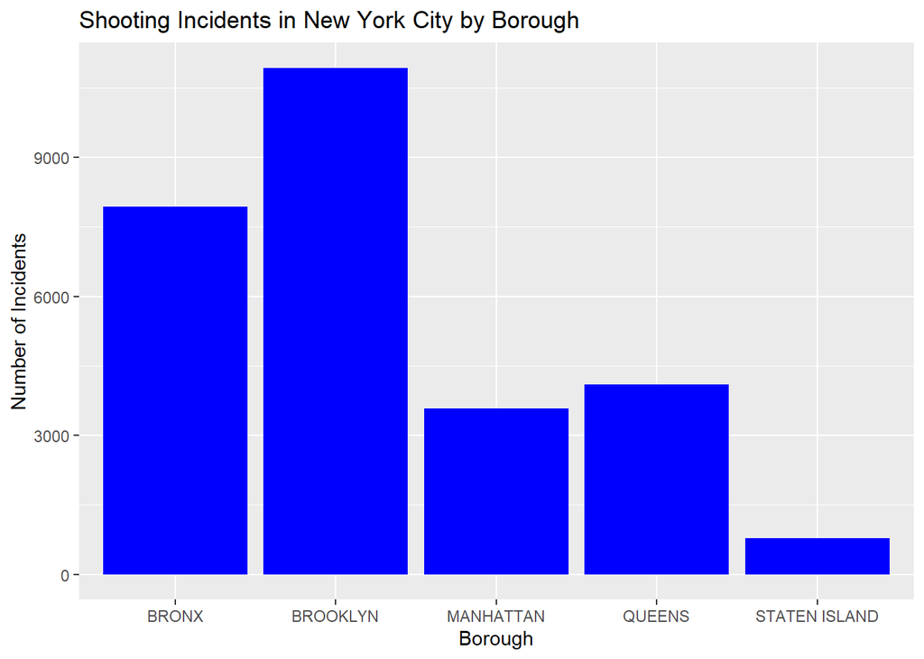

```r
ny_boro_incidents %>%
  ggplot(aes(x = BORO, y = Incidents)) +
  geom_bar(stat = 'identity', fill = "blue") +
  labs(title = "Shooting Incidents in New York City by Borough", x = "Borough",
       y = "Number of Incidents")
```

This visualization provides insight into how shooting incidents occur over geographic area. Between the 2006 and 2022 period, the most shooting incidents occurred in Brooklyn, followed by the Bronx, Queens, Manhattan, and Staten Island. However, this raises an additional question - how does this vary over time? This can be investigated by categorizing the data by year.

#### Transforming the Data

```r
ny_boro_time <- nypd_data %>%
  #organize data by year.
  mutate(Year = floor_date(OCCUR_DATE, "year")) %>%
  #group by borough and time
  group_by(Year, BORO) %>%
  summarize(Incidents = n())

summary(ny_boro_time)
```

```
##       Year                BORO             Incidents
##  Min.   :2006-01-01   Length:85          Min.   : 25.0
##  1st Qu.:2010-01-01   Class :character   1st Qu.:144.0
##  Median :2014-01-01   Mode  :character   Median :278.0
##  Mean   :2013-12-31                      Mean   :321.3
##  3rd Qu.:2018-01-01                      3rd Qu.:520.0
##  Max.   :2022-01-01                      Max.   :850.0
```

Since there was no missing data in the previous frame from which this data frame was derived, there should still be no missing data.

#### Visualizing the Data

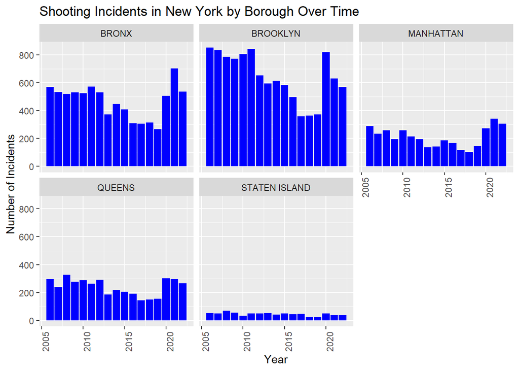

```r
ny_boro_time %>%
  #do things a bit differently - year as independent variable
  ggplot(aes(x = Year, y = Incidents)) +
  geom_bar(stat = 'identity', fill = "blue") +
  #create five graphs on the same axes for each borough
  facet_wrap(~BORO) +
  theme(axis.text.x = element_text(angle = 90)) +
  labs(title= "Shooting Incidents in New York by Borough Over Time",
       y = "Number of Incidents")
```

#### Analysis and Future Directions

```r
#max number of shooting incidents for each borough
aggregate(x = ny_boro_time$Incidents,
          by = list(ny_boro_time$BORO),
          FUN = max)
```

```
##         Group.1   x
## 1         BRONX 701
## 2      BROOKLYN 850
## 3     MANHATTAN 343
## 4        QUEENS 326
## 5 STATEN ISLAND  69
```

```r
#mean number of shooting incidents for each borough
aggregate(x = ny_boro_time$Incidents,
          by = list(ny_boro_time$BORO),
          FUN = mean)
```

```
##         Group.1         x
## 1         BRONX 466.88235
## 2      BROOKLYN 643.11765
## 3     MANHATTAN 210.11765
## 4        QUEENS 240.82353
## 5 STATEN ISLAND  45.64706
```

These visualization provides more insight into the trends over time concerning the shooting incidents across boroughs in New York City. The latter visualization provides context related to shooting incidents between 2006 and 2022. In a given year, Brooklyn has the highest number of shooting incidents, with the exception of 2021 where the Bronx did.

The mean and max numbers of shooting incidents have been presented above for each borough. The boroughs have seen a general decrease in the number of shooting incidents between 2017-2019, followed by an increase in the number of shooting incidents between 2020-2022 (using 2016 as a baseline).

Additional questions that arise from this analysis out of the scope of this report include understanding the context of these values per capita of each borough and analyzing motivations or causes (including historic events) for these shooting incidents.

### Model - Incidents Over Time

#### The Question

**Main question**: Can patterns in the number of shooting incidents over time be observed and predictions about the number of shooting incidents for future time periods be made?

#### Transforming the Data

To answer this question, this data can be transformed to represent monthly instead of daily data. Patterns over time may be easier to observe in this format.

```r
#calculate the number of shootings per month.
ny_monthly_incidents <- nypd_data %>%
  #create a variable that takes the "floor" of each month - the 1st
  mutate(Month = floor_date(OCCUR_DATE, "month")) %>%
  group_by(Month) %>%
  #sum the number of incidents per month.
  summarize(Shooting_Incidents = n())

#exploratory checks - max number of incidents in a day and data head structure.
max(ny_monthly_incidents$Shooting_Incidents)
```

```
## [1] 325
```

```r
head(ny_monthly_incidents)
```

```
## # A tibble: 6 × 2
##   Month      Shooting_Incidents
##   <date>                  <int>
## 1 2006-01-01                129
## 2 2006-02-01                 97
## 3 2006-03-01                102
## 4 2006-04-01                156
## 5 2006-05-01                173
## 6 2006-06-01                180
```

```r
summary(ny_monthly_incidents)
```

```
##      Month            Shooting_Incidents
##  Min.   :2006-01-01   Min.   : 41.00
##  1st Qu.:2010-03-24   1st Qu.: 96.75
##  Median :2014-06-16   Median :124.50
##  Mean   :2014-06-16   Mean   :133.88
##  3rd Qu.:2018-09-08   3rd Qu.:169.25
##  Max.   :2022-12-01   Max.   :325.00
```

There is no missing data in this data frame. No imputation or missing data measures are needed.

Note that the date format lists every month as the “first” of the month. This is acceptable, as R’s date format requires a “day” for its structure. For the purposes of the analysis, this will not affect the results.

#### Visualizing the Data

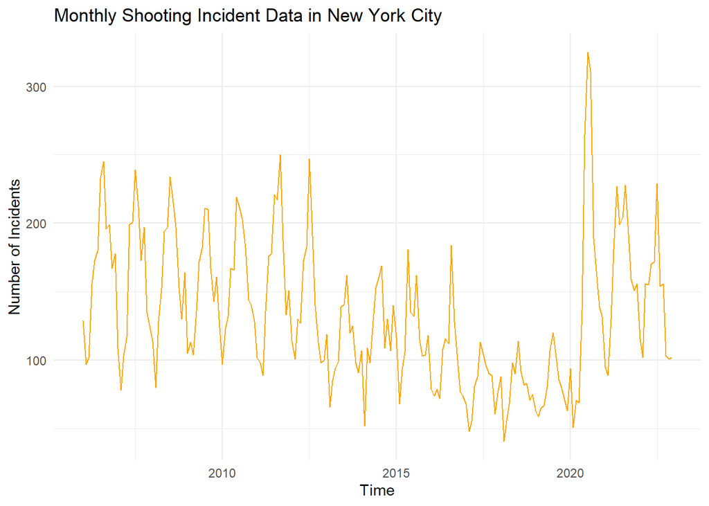

```r
ny_monthly_incidents %>%
  ggplot(aes(x = Month, y = Shooting_Incidents)) +
  #plot a line graph of the incidents.
  #do want to see trends here, so it's fine to have a connected series.
  geom_line(color = "orange") +
  #some aesthetic considerations
  theme_minimal()+
  labs(title = "Monthly Shooting Incident Data in New York City",
       x = "Time",
       y = "Number of Incidents")
```

Upon first glance, there appears to be some seasonality in the data. This will be investigated further. Some crests and troughs are present. A large number of incidents can be seen in mid-2020. While there is some variation present, the number of incidents is not increasing or decreasing rapidly over time.

#### Converting the Data into a Time Series

The data needs to be in the appropriate format for a time series to investigate further. This can be done by converting the data into a “ts” class.

```r
#confirm the minimum and maximum dates in the data
min(ny_monthly_incidents$Month)
```

```
## [1] "2006-01-01"
```

```r
max(ny_monthly_incidents$Month)
```

```
## [1] "2022-12-01"
```

```r
ny_monthly_ts <- ts(ny_monthly_incidents$Shooting_Incidents,
                    #add start and end dates based on min and max
                    start = c(2006,1),
                    end = c(2022,12),
                    #specify monthly data
                    frequency = 12)
```

Now that the data is in a time series format, a seasonality chart can be created using the **forecast** package.

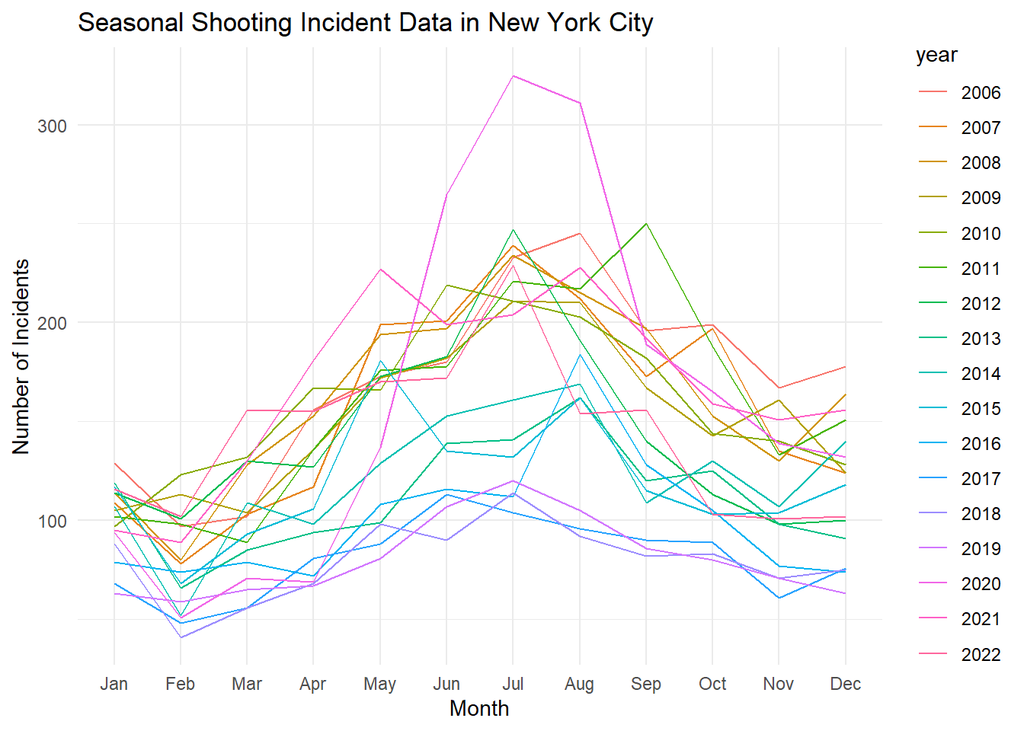

```r
ggseasonplot(ny_monthly_ts) +
  theme_minimal() +
  labs(title = "Seasonal Shooting Incident Data in New York City",
       y = "Number of Incidents")
```

The seasonal data visualization shows that there is some seasonality present. More shooting incidents are reported during the months in the middle of the year, with lower numbers observed during the first few and last few months of the year. The data is not differenced, as it represents month-to-month values (not the change between months). These considerations will be taken into account as a preliminary ARIMA model will be created.

#### Modelling the Data - ARIMA

For the purposes of this analysis, the auto.arima() function in the forecast package will be used, but a visualization of the ACF and PACF values will be presented to show the strength of the model.

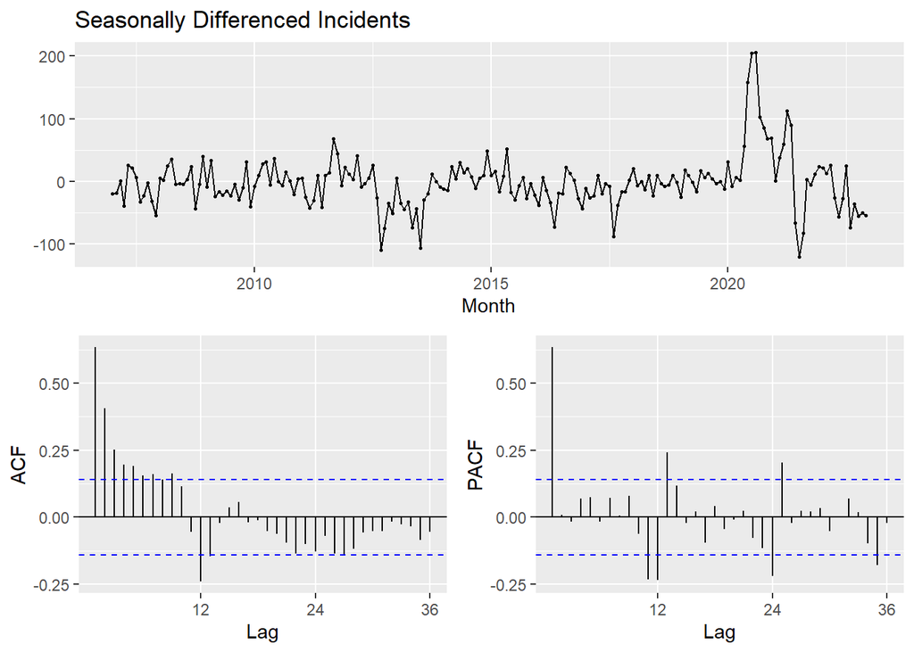

```r
ny_monthly_ts %>%
  diff(lag = 12) %>% #seasonal difference
  ggtsdisplay(xlab = "Month",
              main = "Seasonally Differenced Incidents")
```

```r
#fit data
ny_fit <- auto.arima(ny_monthly_ts)
summary(ny_fit) #print summary to validate model.
```

```
## Series: ny_monthly_ts
## ARIMA(1,0,0)(1,1,0)[12] with drift
##
## Coefficients:
##          ar1     sar1    drift
##       0.6803  -0.3835  -0.1351
## s.e.  0.0532   0.0689   0.4114
##
## sigma^2 = 917.1:  log likelihood = -927.02
## AIC=1862.04   AICc=1862.25   BIC=1875.07
##
## Training set error measures:
##                       ME     RMSE     MAE       MPE     MAPE     MASE
## Training set -0.02437165 29.14876 21.3069 -2.240472 16.99186 0.767672
##                     ACF1
## Training set -0.08032225
```

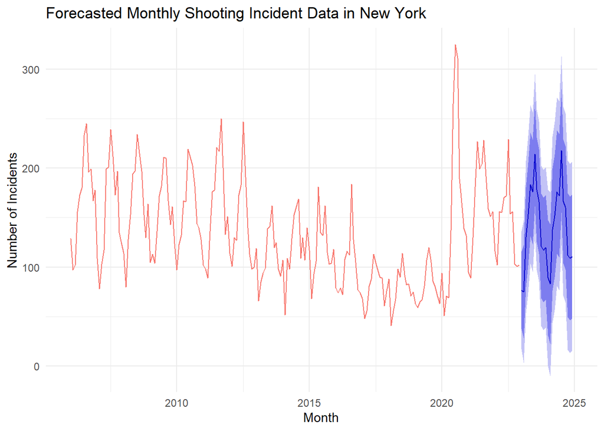

```r
autoplot(forecast(ny_fit)) +
  aes(color = "orange") +
  xlab("Month") +
  ylab("Number of Incidents") +
  ggtitle("Forecasted Monthly Shooting Incident Data in New York") +
  theme_minimal()+
  theme(legend.position = "none")
```

#### Analysis and Future Directions

```r
#Look at first few values of model.
forecast(ny_fit, h =12)
```

```
##          Point Forecast     Lo 80    Hi 80     Lo 95    Hi 95
## Jan 2023       76.75371  37.94400 115.5634  17.39938 136.1080
## Feb 2023       75.07614  28.13653 122.0157   3.28820 146.8641
## Mar 2023      130.38729  80.12805 180.6465  53.52241 207.2522
## Apr 2023      153.61105 101.88740 205.3347  74.50656 232.7155
## May 2023      183.41269 131.02511 235.8003 103.29280 263.5326
## Jun 2023      175.89128 123.19923 228.5833  95.30575 256.4768
## Jul 2023      214.29982 161.46745 267.1322 133.49968 295.1000
## Aug 2023      178.18065 125.28346 231.0778  97.28138 259.0799
## Sep 2023      166.23321 113.30604 219.1604  85.28809 247.1783
## Oct 2023      121.32726  68.38623 174.2683  40.36093 202.2936
## Nov 2023      117.31541  64.36796 170.2629  36.33927 198.2916
## Dec 2023      120.04586  67.09543 172.9963  39.06517 201.0265
```

By using an ARIMA model to forecast future shooting incidents, predictions can be made about the number of shooting incidents in future years. By using a ARIMA(1,0,0)(1,1,0)[12] model, a time series is forecasted with an AICc of 1862.25 and a RMSE of 29.14876. For the purposes of this analysis, this is a simple model that uses all of the given data as training data.

The table above presents the expected number of shootings predicted by the model over 2023. While this year has elapsed, data is not available in the given data set for this time frame. The point forecasts indicate that the 2023 year will start with 76 incidents, “peak” in July with 214, and end in December with 120. This pattern loosely follows the seasonal trend observed in the data.

One future direction that could be explored is to compare the model to actual data once the 2023 shooting incident reports have been released. Additional questions that may arise from this analysis may include how the forecasts may vary with other variables by integrating regression into the model, an investigation into the seasonality of shooting incidents, and further analysis regarding temporal shooting incident data by borough.

### Conclusion

#### Sources of Bias

The visualizations and analysis presented in this report do provide some insight in to the trends and patterns involved in New York shooting incidents. However, it is important to examine potential sources of bias when drawing conclusions about the results.

One potential source of bias is a systemic consideration. The data represents reported incident data. Are there situations in which an incident was not reported? What factors play in to this potential under-representation of data, and how might the data look different these potentially unreported incidents are considered?

The way in which incidents are captured may contribute to bias. There is no context included in the data, such as motivations or reasons for the incidents. This data could aid in better understanding the data and affect the conclusions made. Understanding potential causes for outliers could also be reached with more information, such as historic events related to shooting incidents. The footnotes of the data state that incidents with multiple victims are represented using they same key, but no other information is provided.

Additionally, as mentioned in the heatmap data introduction, is that geolocation data has some specific encoding when it comes to the recorded values. These serve as a form of bias. “High-crime areas” may correlate with high-traffic areas, which should be investigated further.

Political information may also be intertwined in the data and could aid in understanding the observed trends. Variables such as perceptions around gun control, the presence of organized criminal activity, and relevant laws or statutes passed may be of importance.

Although this analysis does not include models involving race and gender, it is important to be mindful of how these variables are used in a potential model.

It is possible that personal biases influenced to the data analysis. Topics of contention that have the potential to influence the analysis include pro-gun control, considerations for police reform, and perceptions of Americans as a non-citizen and non-resident of America. To mitigate personal bias, the analysis presented is focused on objective results found in the analysis. The conclusions drawn pertain only to what can be found statistically and superfluous assertions have been minimized. While systemic biases cannot fully be mitigated, they have been recorded above to promote transparency in data analysis.

#### Conclusion

The report presented has produced results related to the temporal and geospatial nature of shooting incidents in New York City. However, there are many future directions that can be taken to understand the holistic nature of firearm activity in New York.